# FinalProject_LogisticRegression

ReedFrellick

2022-04-10

## Creating the Data set

```r
teams_cleaned <- read.csv("all_teams_cleaned.csv")

teams_subsetted <- teams_cleaned %>% select(5:7, 18:36, 46:49, 66:84, 94:97, 104, -goalsFor, -goalsAgainst, -reboundGoalsFor, -reboundGoalsAgainst, -scoreAdjustedShotsAttemptsFor, -scoreAdjustedShotsAttemptsAgainst, -scoreAdjustedUnblockedShotAttemptsFor, -scoreAdjustedUnblockedShotAttemptsAgainst, -savedShotsOnGoalFor, -savedShotsOnGoalAgainst)

teams_subsetted <- teams_cleaned %>% select(-contains("x"), -goalsFor, -reboundGoalsFor, -lowDangerGoalsFor, -mediumDangerGoalsFor, -highDangerGoalsFor, -goalsAgainst, -reboundGoalsAgainst, -lowDangerGoalsAgainst, -mediumDangerGoalsAgainst, -highDangerGoalsAgainst, -team, -season, -opposingTeam, -iceTime, -contains("Adjusted"), -contains("Danger"), -contains("Credit"), -contains("Percentage"), -missedShotsFor , -shotAttemptsFor , -reboundsFor , -freezeFor , -playStoppedFor , -playContinuedInZoneFor , -savedShotsOnGoalFor , -savedUnblockedShotAttemptsFor , -penaltiesFor , -unblockedShotAttemptsFor , -shotsOnGoalAgainst , -missedShotsAgainst , -blockedShotAttemptsAgainst , -shotAttemptsAgainst , -reboundsAgainst , -playContinuedOutsideZoneAgainst , -savedShotsOnGoalAgainst)
```

## Logistic Regression with Cross Validated Model Selection

```r
#Rough plan:
# - split data into train and test
# - use cv to do bottom-up model selection --> use cv accuracy for selections
# - keep strongest models and compare

set.seed(6212)
train_data_offsets = sample(1:nrow(teams_subsetted), .8 * nrow(teams_subsetted))
train_data1 <- teams_subsetted[train_data_offsets,]
test_data1 <- teams_subsetted[-train_data_offsets,]

#Bottom-up model selection

# Start with empty initialized lists for models and accuracies and predictor offset lists
# Initialize reshaped data set to remove predictors
# Iterate through loop from 1 to size of full model
  # Initialize changing actual predictor
  # Iterate through loop to test best model with all previous best predictors and each additional predictor
    # Grab predictor from reshaped data at offset j
    # Find and Save actual offset of predictor
    # Save best model and accuracy in offset that == number of predictors
    # Save list of predictors with actual offset of this predictor added
  # Delete predictor from this round out of reshapable data

bottomUp <- function(train_data, test_data){
#models = c()
accuracies = c()
offsets = c()
reshaped_data = train_data
data_names = colnames(train_data)

for (i in 1:(ncol(train_data)-1)) {
  predictor = -1
  predictor2 = -1
  for (j in 1:(ncol(reshaped_data)-1)) {
    pred = reshaped_data[j]
    pred_offset = offset_finder(data_names, colnames(reshaped_data[j]))
    preds = c(offsets[1:i-1], pred_offset)
    this_model_data = train_data %>% select(as.vector(preds), ncol(train_data))
    this_model_test = test_data %>% select(as.vector(preds), ncol(train_data))
    this_model = glm(isWin ~., data = this_model_data, family = "binomial")
    this_preds = cutoff_func(predict(this_model, this_model_test, type="response"),.5)
    #this_acc = accuracy_func(this_preds, this_model_data[ncol(this_model_data)])
    this_acc = sum(this_model_test[ncol(this_model_test)] == this_preds) / length(this_preds)
    if (is.null(accuracies[i])){
      accuracies[i] = this_acc
      #models[i] = this_model
      offsets = preds
      predictor = pred_offset
      predictor2 = j
    } else if (is.na(accuracies[i])){
      accuracies[i] = this_acc
      #models[i] = this_model
      offsets = preds
      predictor = pred_offset
      predictor2 = j
    } else if(this_acc > accuracies[i]){
      accuracies[i] = this_acc
      #models[i] = this_model
      offsets = preds
      predictor = pred_offset
      predictor2 = j
    }
  }
  reshaped_data = reshaped_data %>% select(-predictor2)
}
return(c(offsets, accuracies))
}

offset_finder = function(names, name){
  for (i in 1:length(names)){
    if (name==names[i]){
      return(i)
    }
  }
  return(NA)
}

accuracy_func = function(preds, actual){
  correct = sum(preds == actual)
  acc = correct / length(preds)
  return(acc)
}

cutoff_func = function(preds, cutoff){
  newpreds = preds > cutoff
  return(newpreds)
}

conf_matrix <- function(threshold, predVals, realVals){
  predicted_values<-ifelse(predVals>threshold,1,0)
  conf_matrix<-table(predicted_values, realVals)
  return(conf_matrix)
}

accuracy_func_conf <- function(confMat){
  correct = confMat[1,1] + confMat[2,2]
  total = sum(confMat)
  acc = correct/total
  return(acc)
}

sens_func = function(confMat){
  sens = confMat[2,2] / (confMat[2,2] + confMat[1,2])
  return(sens)
}

spec_func = function(confMat){
  spec = confMat[1,1] / (confMat[1,1] + confMat[2,1])
  return(spec)
}

model_from_offset = function(offset, train, bottomUpList){
  predictorsWanted <- train %>% select(bottomUpList[1:offset], isWin)
  modelWanted <- glm(isWin ~., data= predictorsWanted)
  return(modelWanted)
}

logBottomUpSelection <- bottomUp(train_data1, test_data1)

summaryStats <- data.frame(matrix(nrow=length(logBottomUpSelection)/2, ncol = 6))

columnNames = c("modelSize", "newVariable", "accuracy", "sensitivity", "specificity", "AUC")

colnames(summaryStats) = columnNames

variableNames = colnames(train_data1)[logBottomUpSelection[1:(length(logBottomUpSelection)/2)]]

for (i in 1:nrow(summaryStats)){
  this_model1 = model_from_offset(i, train_data1, logBottomUpSelection)

  confMat = conf_matrix(.5, predict(this_model1, test_data1, type="response"), test_data1$isWin)

  summaryStats$modelSize[i] = i
  summaryStats$newVariable[i] = variableNames[i]
  summaryStats$accuracy[i] = accuracy_func_conf(confMat)
  summaryStats$sensitivity[i] = sens_func(confMat)
  summaryStats$specificity[i] = spec_func(confMat)
  summaryStats$AUC[i] = roc(test_data1$isWin, predict(this_model1, test_data1, type="response"))$auc
}
```

## Displaying results of Logistic model selection

In each of the plots below, you can see the summary statistics for the best model of each model size based on the bottom-up model selection. Notably there is a large jump in model accuracy in the 15 variable model- this is due to the inclusion of `unblockedShotAttemptsAgainst` and `savedUnblockedShotAttemptsAgainst`, which together will give the model a linear combination to find a rough estimate of `goalsAgainst`, which we do not include in the set of predictors we allow because of its strong ability of predict the results of games on it’s own or especially when combined with `goalsFor`. The most accuracy single predictor model included the predictor `blockedShotAttemptsFor`. A full list of the models and their successively added predictors can be found below the plots.

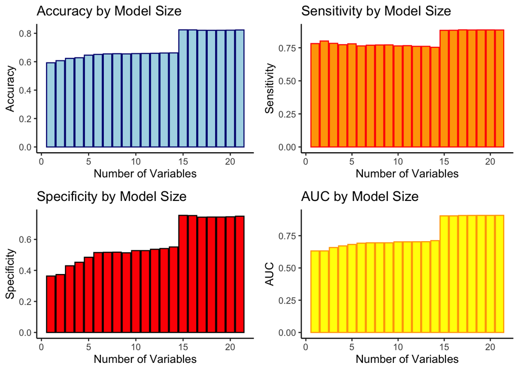

```r
acc1 <- ggplot(data=summaryStats, aes(modelSize, accuracy)) + geom_bar(stat = "identity", col="navy", fill= "lightblue") + theme_classic() + xlab("Number of Variables") + ylab("Accuracy") + ggtitle("Accuracy by Model Size")

sens1 <- ggplot(data=summaryStats, aes(modelSize, sensitivity)) + geom_bar(stat = "identity", col="red", fill= "orange") + theme_classic() + xlab("Number of Variables") + ylab("Sensitivity") + ggtitle("Sensitivity by Model Size")

spec1 <- ggplot(data=summaryStats, aes(modelSize, specificity)) + geom_bar(stat = "identity", col="black", fill= "red") + theme_classic() + xlab("Number of Variables") + ylab("Specificity") + ggtitle("Specificity by Model Size")

AUC1 <- ggplot(data=summaryStats, aes(modelSize, AUC)) + geom_bar(stat = "identity", col="orange", fill= "yellow") + theme_classic() + xlab("Number of Variables") + ylab("AUC") + ggtitle("AUC by Model Size")

ggarrange(acc1, sens1, spec1, AUC1, ncol=2, nrow=2)
```

```r
summaryStats %>% kbl() %>% kable_styling(c("striped", "hover"), full_width = T)
```

| modelSize | newVariable | accuracy | sensitivity | specificity | AUC |
| --- | --- | --- | --- | --- | --- |
| 1 | blockedShotAttemptsFor | 0.5923952 | 0.7816764 | 0.3639216 | 0.6320068 |
| 2 | takeawaysAgainst | 0.6073205 | 0.8011696 | 0.3733333 | 0.6322139 |
| 3 | takeawaysFor | 0.6233120 | 0.7836257 | 0.4298039 | 0.6580813 |
| 4 | hitsAgainst | 0.6279318 | 0.7732294 | 0.4525490 | 0.6709307 |
| 5 | hitsFor | 0.6460554 | 0.7797271 | 0.4847059 | 0.6818902 |
| 6 | playContinuedInZoneAgainst | 0.6513859 | 0.7641326 | 0.5152941 | 0.6920995 |
| 7 | playContinuedOutsideZoneFor | 0.6549396 | 0.7693307 | 0.5168627 | 0.6948688 |
| 8 | penalityMinutesFor | 0.6563611 | 0.7712801 | 0.5176471 | 0.6949218 |
| 9 | dZoneGiveawaysFor | 0.6549396 | 0.7719298 | 0.5137255 | 0.6949035 |
| 10 | giveawaysFor | 0.6570718 | 0.7641326 | 0.5278431 | 0.7022533 |
| 11 | dZoneGiveawaysAgainst | 0.6581379 | 0.7660819 | 0.5278431 | 0.7025458 |
| 12 | playStoppedAgainst | 0.6592040 | 0.7608837 | 0.5364706 | 0.7028598 |
| 13 | faceOffsWonFor | 0.6613362 | 0.7608837 | 0.5411765 | 0.7035625 |
| 14 | unblockedShotAttemptsAgainst | 0.6620469 | 0.7537362 | 0.5513725 | 0.7117191 |
| 15 | savedUnblockedShotAttemptsAgainst | 0.8244492 | 0.8817414 | 0.7552941 | 0.9036879 |
| 16 | freezeAgainst | 0.8240938 | 0.8823912 | 0.7537255 | 0.9036803 |
| 17 | shotsOnGoalFor | 0.8212509 | 0.8856400 | 0.7435294 | 0.9063349 |
| 18 | faceOffsWonAgainst | 0.8208955 | 0.8843405 | 0.7443137 | 0.9068104 |
| 19 | penalityMinutesAgainst | 0.8212509 | 0.8849903 | 0.7443137 | 0.9072492 |
| 20 | penaltiesAgainst | 0.8219616 | 0.8849903 | 0.7458824 | 0.9071972 |
| 21 | giveawaysAgainst | 0.8233831 | 0.8843405 | 0.7498039 | 0.9077873 |

## Building the rate statistics data set

```r
#building in season long cumulative statistics for teams as predictors
homeTeamRates <- teams_cleaned %>%
  group_by(team, season) %>%
  summarise(
    n = n(),
    goalsForRate = sum(goalsFor)/n,
    shotsOnGoalForRate = sum(shotsOnGoalFor)/n,
    missedShotsForRate = sum(missedShotsFor)/n,
    blockedShotAttemptsForRate = sum(blockedShotAttemptsFor)/n,
    shotAttemptsForRate = sum(shotAttemptsFor)/n,
    reboundsForRate = sum(reboundsFor)/n,
    reboundGoalsForRate = sum(reboundGoalsFor)/n,
    freezeForRate = sum(freezeFor)/n,
    playStoppedForRate = sum(playStoppedFor)/n,
    playContinuedInZoneForRate = sum(playContinuedInZoneFor)/n,
    playContinuedOutsideZoneForRate = sum(playContinuedOutsideZoneFor)/n,
    savedShotsOnGoalForRate = sum(savedShotsOnGoalFor)/n,
    savedUnblockedShotAttemptsForRate = sum(savedUnblockedShotAttemptsFor)/n,
    penaltiesForRate = sum(penaltiesFor)/n,
    penaltyMinutesForRate = sum(penalityMinutesFor)/n,
    faceOffsWonForRate = sum(faceOffsWonFor)/n,
    hitsForRate = sum(hitsFor)/n,
    takeawaysForRate = sum(takeawaysFor)/n,
    giveawaysForRate = sum(giveawaysFor)/n,
    #isWinForRate = sum(isWin)/n
  ) %>% select(-n)

awayTeamRates <- teams_cleaned %>%
  group_by(opposingTeam, season) %>%
  summarise(
    n = n(),
    goalsAgainstRate = sum(goalsAgainst)/n,
    shotsOnGoalAgainstRate = sum(shotsOnGoalAgainst)/n,
    missedShotsAgainstRate = sum(missedShotsAgainst)/n,
    blockedShotAttemptsAgainstRate = sum(blockedShotAttemptsAgainst)/n,
    shotAttemptsAgainstRate = sum(shotAttemptsAgainst)/n,
    reboundsAgainstRate = sum(reboundsAgainst)/n,
    reboundGoalsAgainstRate = sum(reboundGoalsAgainst)/n,
    freezeAgainstRate = sum(freezeAgainst)/n,
    playStoppedAgainstRate = sum(playStoppedAgainst)/n,
    playContinuedInZoneAgainstRate = sum(playContinuedInZoneAgainst)/n,
    playContinuedOutsideZoneAgainstRate = sum(playContinuedOutsideZoneAgainst)/n,
    savedShotsOnGoalAgainstRate = sum(savedShotsOnGoalAgainst)/n,
    savedUnblockedShotAttemptsAgainstRate = sum(savedUnblockedShotAttemptsAgainst)/n,
    penaltiesAgainstRate = sum(penaltiesAgainst)/n,
    penaltyMinutesAgainstRate = sum(penalityMinutesAgainst)/n,
    faceOffsWonAgainstRate = sum(faceOffsWonAgainst)/n,
    hitsAgainstRate = sum(hitsAgainst)/n,
    takeawaysAgainstRate = sum(takeawaysAgainst)/n,
    giveawaysAgainstRate = sum(giveawaysAgainst)/n,
    #isWinAgainstRate = sum(isWin)/n
  ) %>% select(-n)

#ARI is missing home game data for 2011-2013; I'm going to do the data joining and get rid of any games where they are the home team during those seasons

simplifiedTeamSeason <- teams_cleaned %>% select(team, season, opposingTeam, isWin)

team_cleaned_rates <- left_join(left_join(simplifiedTeamSeason, homeTeamRates, by = c("team", "season")), awayTeamRates, by = c("opposingTeam", "season")) %>% relocate(isWin, .after = giveawaysAgainstRate) %>% select(-team, -opposingTeam, -season)
```

## Rate statistics over the course of a season as predictors (perhaps for playoff matchups)

- Create data set for each team and season and home/away that gives there home and away combined rate statistics
- for each observation, add that data as rateFor and rateAgainst for home and away team, respectively
- Use these statistics to predict wins and losses

```r
set.seed(4502)
train_data_offsets2 = sample(1:nrow(team_cleaned_rates), .8 * nrow(team_cleaned_rates))
train_rates <- team_cleaned_rates[train_data_offsets,]
test_rates <- team_cleaned_rates[-train_data_offsets,]

rateLog <- bottomUp(train_rates, test_rates)

cat("Best model accuracy after model selection for rate statistics:")
```

```
## Best model accuracy after model selection for rate statistics:
```

```r
max(rateLog[39:length(rateLog)])
```

```
## [1] 0.6240227
```